# U.S. Medical Insurance Costs

This project explores the **US medical insurance dataset** (available at https://www.kaggle.com/datasets/teertha/ushealthinsurancedataset). The goal is to clean, analyze, and uncover insights about factors that influence insurance charges. The analysis is structured in five steps: data loading, exploration, cleaning, analysis, and conclusions.

## 1. Data Loading

First, we import the necessary libraries and load the dataset into a Pandas DataFrame.

```python
import pandas as pd

#importing and looking at the file format
insurance_data = pd.read_csv("insurance.csv")
print(insurance_data.head())
```

```
   age     sex     bmi  children smoker     region      charges
0   19  female  27.900         0    yes  southwest  16884.92400
1   18    male  33.770         1     no  southeast   1725.55230
2   28    male  33.000         3     no  southeast   4449.46200
3   33    male  22.705         0     no  northwest  21984.47061
4   32    male  28.880         0     no  northwest   3866.85520
```

## 2. Data Exploration

We start by exploring the first few rows of the dataset and checking basic info to understand the structure and types of data we are working with.

```python
import pandas as pd

#importing and looking at the file format
insurance_data = pd.read_csv("insurance.csv")
print(insurance_data.head())
```

```
   age     sex     bmi  children smoker     region      charges
0   19  female  27.900         0    yes  southwest  16884.92400
1   18    male  33.770         1     no  southeast   1725.55230
2   28    male  33.000         3     no  southeast   4449.46200
3   33    male  22.705         0     no  northwest  21984.47061
4   32    male  28.880         0     no  northwest   3866.85520
```

## 3. Data Cleaning

We check for missing values and clean the dataset if needed. This ensures the data is ready for analysis.

```python
# Verifying there are no empty/null values
insurance_data.isnull().sum()
```

```
age         0
sex         0
bmi         0
children    0
smoker      0
region      0
charges     0
dtype: int64
```

## 4. Data Analysis

We perform an analysis of the dataset, exploring relationships between variables such as age, BMI, smoking status, and insurance charges.

```python
print(insurance_data.describe().round(2))
```

```
           age      bmi  children   charges
count  1338.00  1338.00   1338.00   1338.00
mean     39.21    30.66      1.09  13270.42
std      14.05     6.10      1.21  12110.01
min      18.00    15.96      0.00   1121.87
25%      27.00    26.30      0.00   4740.29
50%      39.00    30.40      1.00   9382.03
75%      51.00    34.69      2.00  16639.91
max      64.00    53.13      5.00  63770.43
```

```python
# Average charges by categorical variables
print(insurance_data.groupby("sex")["charges"].mean().round(2))
print(insurance_data.groupby("smoker")["charges"].mean().round(2))
print(insurance_data.groupby("region")["charges"].mean().round(2))
```

```
sex
female    12569.58
male      13956.75
Name: charges, dtype: float64
smoker
no      8434.27
yes    32050.23
Name: charges, dtype: float64
region
northeast    13406.38
northwest    12417.58
southeast    14735.41
southwest    12346.94
Name: charges, dtype: float64
```

```python
# BMI average by categorical variables
print(insurance_data.groupby("sex")["bmi"].mean().round(2))
print(insurance_data.groupby("smoker")["bmi"].mean().round(2))
print(insurance_data.groupby("region")["bmi"].mean().round(2))
```

```
sex
female    30.38
male      30.94
Name: bmi, dtype: float64
smoker
no     30.65
yes    30.71
Name: bmi, dtype: float64
region
northeast    29.17
northwest    29.20
southeast    33.36
southwest    30.60
Name: bmi, dtype: float64
```

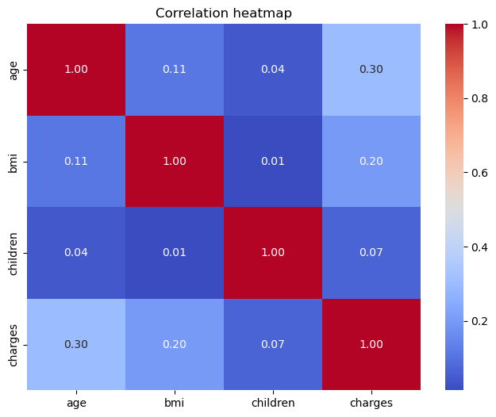

```python
# Visualization - importing libraries and creating heatmap of num correlations
import seaborn as sns
import matplotlib.pyplot as plt

correlations = insurance_data.corr(numeric_only=True)
plt.figure(figsize=(8,6))
sns.heatmap(correlations, annot=True, cmap="coolwarm", fmt=".2f")
plt.title("Correlation heatmap")
plt.show()
```

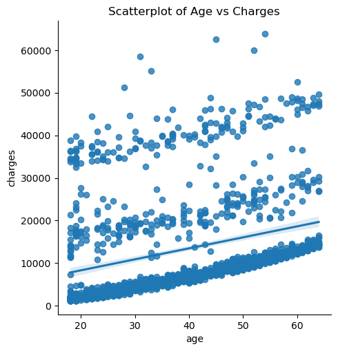

```python
# Scatterplot with regression line of statistically relevant numeric variables (age and BMI)
sns.lmplot(x="age", y="charges", data=insurance_data)
plt.title("Scatterplot of Age vs Charges")
plt.savefig("images/bmi_vs_charges.png", dpi=300, bbox_inches="tight")
plt.show()
```

```python
sns.lmplot(x="bmi", y="charges", data=insurance_data)
plt.title("Scatterplot of bmi vs Charges")
plt.show()
```

[output not shown]

## 5. Conclusions

From the analysis, we can summarize:

- Age and BMI show a correlation with insurance charges.
- Smokers tend to have significantly higher insurance costs.
- Region has less of an effect compared to lifestyle factors.

This project demonstrates how data analysis can uncover key drivers of insurance costs.